[figure not shown]

[figure not shown]

Indicadores migratorios  
Túnez

[Observatorio Permanente de la Inmigración (OPI) - S.G de Análisis Migratorio (SGAM)](https://inclusion.seg-social.es/web/opi/estadisticas)

Junio 2023

1. Ciudadanos con documentación de residencia en vigor

2. Ciudadanos con otro tipo de documentación

3. Perfil sociodemográfico y distribución territorial

4. Afiliación en alta laboral y paro registrado

5. Nacionalizados españoles por residencia

6. Solicitantes de Protección Internacional

7. Beneficiarios del Sistema de Acogida y del programa de Atención Humanitaria

8. Menores extranjeros no acompañados y jóvenes extutelados (de 16 a 23 años)

9. Evolución de los flujos regulares (visados y documentación de residencia)

10. Población española residente en Túnez

# 1. Ciudadanos con documentación de residencia en vigor

A fecha 31/12/2022 constaban **2.428 ciudadanos de nacionalidad tunecina con documentación de residencia en vigor en España**:

- 1.727 con autorización sujeta al régimen de extranjería en alguna de las modalidades previstas en la normativa de extranjería española.
- 701 con tarjeta de familiar de ciudadano UE/AELC en régimen de Libre Circulación en virtud de sus vínculos familiares con algún ciudadano de la UE/AELC.
- 0 con documento (TIE) sujeto al régimen del Acuerdo de Retirada como familiar de ciudadano británico beneficiario del acuerdo (iniciado el 6 de julio de 2020) motivado por el Brexit.

Nacionales de Túnez con autorización de residencia según motivo de concesión. 31/12/2022

| Motivo | Personas | % |
| --- | --- | --- |
| TOTAL | 1.727 | 100 |
| Residencia larga duración nacional | 922 | 53 |
| Residencia temporal. Ley 14/2013 y otras | 306 | 18 |
| Residencia temporal. Circunstancias excepcionales | 91 | 5 |
| Residencia por protección internacional | 87 | 5 |
| Residencia temporal. Reagrupación familiar | 87 | 5 |
| Residencia larga duración directiva UE | 83 | 5 |
| Residencia temporal no lucrativa | 72 | 4 |
| Residencia temporal. Trabajo por cuenta ajena | 54 | 3 |
| Residencia temporal. Compatibilidad cuenta ajena y propia | 15 | 1 |
| Residencia temporal. Trabajo por cuenta propia | 7 | 0 |
| Residencia temporal. Excepción a la autorización de trabajo | 3 | 0 |

Fuente: [OPI-SGAM](https://inclusion.seg-social.es/web/opi/estadisticas/catalogo/extranjeros_con_certificado)

Nacionales de Túnez con tarjeta de familiar de ciudadano UE/AELC o con TIE de familiar de británico beneficiario del acuerdo de retirada, según motivo. 31/12/2022

| Modalidad | Personas | % |
| --- | --- | --- |
| TOTAL | 701 | 100 |
| Familiar de UE-RU. Temporal | 381 | 54 |
| Familiar de UE-RU. Permanente | 320 | 46 |

Fuente: [OPI-SGAM](https://inclusion.seg-social.es/web/opi/estadisticas/catalogo/extranjeros_con_certificado)

La comunidad de Túnez representa un **0% de todos los ciudadanos de África documentados en España.**

Nacionales de Túnez con documentación de residencia en España según tipo de documentación en vigor y región. 31/12/2022

| Tipo documentación | Todas las nacionalidades | Nacionales de África | % África respecto Total | NACIONALES DE TÚNEZ | % Túnez respecto África |
| --- | --- | --- | --- | --- | --- |
| TOTAL | 6.493.147 | 1.158.092 | 18 | 2.428 | 0 |
| Autorización | 2.690.247 | 1.051.561 | 39 | 1.727 | 0 |
| Certificado de registro y TIE-Acuerdo de retirada (titular) | 3.213.332 | 0 | 0 | 0 |  |
| Tarjeta familiar de UE-RU y TIE-Acuerdo de retirada (familiar) | 589.568 | 106.531 | 18 | 701 | 1 |

Fuente: [OPI-SGAM](https://inclusion.seg-social.es/web/opi/estadisticas/catalogo/extranjeros_con_certificado)

**En la UE, España ocupa el puesto 6 en número de extranjeros documentados de Túnez**, según datos de Eurostat de finales de 2021.

Nacionales de Túnez con permiso de residencia en cada país de la UE/AELC según tiempo de validez del permiso. 31/12/2021

| Orden | País UE/AELC | TOTAL | De 3 a 5 meses | De 6 a 11 meses | 1 año o más |
| --- | --- | --- | --- | --- | --- |
| 1 | Francia | 261.125 | 3.390 | 13.775 | 243.960 |
| 2 | Italia | 100.103 | 34 | 1.004 | 99.065 |
| 3 | Alemania | 27.023 | 59 | 762 | 26.202 |
| 4 | Suiza | 7.850 | 4 | 27 | 7.819 |
| 5 | Bélgica | 6.980 | 253 | 0 | 6.727 |
| 6 | España | 2.646 | 14 | 298 | 2.334 |
| 7 | Austria | 2.270 | 1 | 90 | 2.179 |
| 8 | Grecia | 1.848 | 0 | 0 | 1.848 |
| 9 | Países Bajos | 1.762 | 1 | 18 | 1.743 |
| 10 | Suecia | 1.602 | 14 | 27 | 1.561 |
| 11 | República Checa | 1.313 | 3 | 17 | 1.293 |
| 12 | Rumanía | 1.170 | 28 | 58 | 1.084 |
| 13 | Polonia | 1.102 | 24 | 137 | 941 |
| 14 | Hungría | 1.070 | 61 | 178 | 831 |
| 15 | Luxemburgo | 1.007 | 2 | 11 | 994 |
| 16 | Portugal | 550 | 1 | 8 | 541 |
| 17 | Malta | 386 | 20 | 38 | 328 |
| 18 | Dinamarca | 383 | 0 | 0 | 383 |
| 19 | Finlandia * | 313 | 2 | 52 | 259 |
| 20 | Noruega | 236 | 0 | 8 | 228 |
| 21 | Irlanda | 212 | 6 | 44 | 162 |
| 22 | Bulgaria | 165 | 2 | 23 | 140 |
| 23 | República Eslovaca | 165 | 0 | 0 | 165 |
| 24 | Eslovenia | 90 | 0 | 5 | 85 |
| 25 | Croacia | 48 | 0 | 3 | 45 |
| 26 | Estonia | 46 | 0 | 0 | 46 |
| 27 | Lituania | 39 | 0 | 1 | 38 |
| 28 | Chipre | 36 | 1 | 10 | 25 |
| 29 | Liechtenstein | 17 | 1 | 0 | 16 |
| 30 | Letonia | 12 | 0 | 5 | 7 |
| - | Islandia | : | : | : | : |

(*) dato de 2020; (:) dato no disponible

Nota: el número de extranjeros con documentación de residencia publicado por OPI-SGAM y el de extranjeros con permiso de residencia publicado por Eurostat no coinciden por tratarse de diferentes estadísticas e incluir cada una de ellas diferentes tipos de documentación de extranjería.

Fuente: [Eurostat](https://ec.europa.eu/eurostat/databrowser/view/migr_resvalid/default/table?lang=en)

# 2. Ciudadanos con otro tipo de documentación

2.1 Personas con autorización de estancia por estudios

A 31/12/2022 constaban **741 nacionales de Túnez documentados con una autorización de estancia por estudios**, 64% hombres y 36% mujeres.

| Tipo de solicitante | TOTAL | Hombres | Mujeres |
| --- | --- | --- | --- |
| TOTAL | 741 | 473 | 268 |
| Estudiante | 732 | 468 | 264 |
| Familiar | 9 | 5 | 4 |

Fuente: [OPI-SGAM](https://inclusion.seg-social.es/web/opi/estadisticas/catalogo/extranjeros_estudios)

2.2 Solicitantes de asilo pendientes de resolución

La información publicada en la web pública de Eurostat indica que, a 30/04/2023 (último dato disponible), había **110 personas de nacionalidad tunecina que tenían pendiente de resolución su solicitud de Protección Internacional**; el 14% mujeres.

Fuente: [Eurostat](https://ec.europa.eu/eurostat/databrowser/view/migr_asypenctzm/default/table?lang=en)

2.3 Empadronados

A fecha de 01/01/2022, la más reciente con datos publicados para Túnez, **constaban empadronados 3.102** nacionales de dicho país.

Y a fecha de 31/12/2021 documentados como residentes, estudiantes o solicitantes de asilo pendientes de resolución habría un total de 3.075 personas, lo que sugiere que 27 personas de nacionalidad tunecina podrían residir en España en aquel momento sin documentación de extranjería en vigor, el 1% del colectivo.

| Documentación | Personas |
| --- | --- |
| Empadronados a 01/01/2022 | 3.102 |
| Con documentación de residencia a 31/12/2021 | 2.179 |
| Con autorización de estancia por estudios a 31/12/2021 | 456 |
| Solicitantes de asilo pendiente de resolución a 31/12/2021 | 440 |
| Empadronados menos documentados | 27 |

Fuente: [Padrón Continuo - INE](https://www.ine.es/dyngs/INEbase/es/operacion.htm?c=Estadistica_C&cid=1254736177012&menu=ultiDatos&idp=1254734710990); [OPI-SGAM](https://inclusion.seg-social.es/web/opi/estadisticas/catalogo); [Eurostat](https://ec.europa.eu/eurostat/databrowser/view/migr_asypenctzm/default/table?lang=en)

# 3. Perfil sociodemográfico y distribución territorial

Nacionales de Túnez con documentación de residencia según sexo y grupo de edad. 31/12/2022

| TOTAL | Hombres | % Hombres | Mujeres | % Mujeres |
| --- | --- | --- | --- | --- |
| 2.428 | 1.489 | 61 | 939 | 39 |

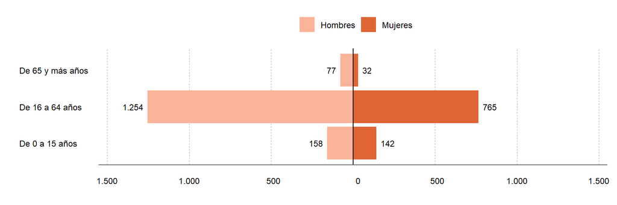

Nacionales de Túnez con documentación de residencia según provincia de residencia, 31/12/2022. Cifras absolutas y porcentaje sobre el total de extranjeros residentes de nacionalidad tunecina

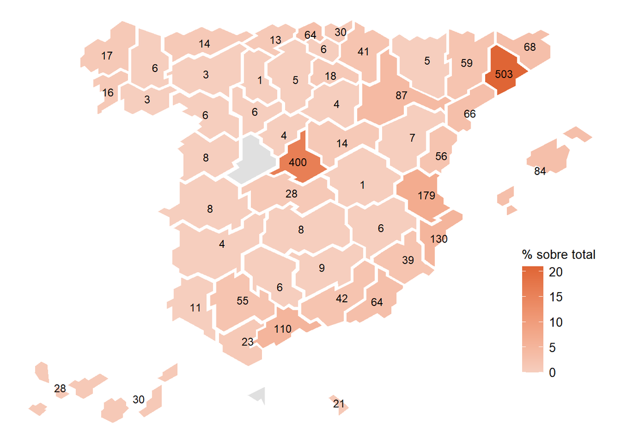

Fuente: [OPI-SGAM](https://inclusion.seg-social.es/web/opi/estadisticas/catalogo/extranjeros_con_certificado)

# 4. Afiliación en alta laboral y paro registrado

4.1 Régimen de afiliación a la Seguridad Social de nacionales de Túnez a 28/04/2023

En España hay **1.314 afiliados de Túnez**, que representan un 0% del total de ciudadanos de países no UE/AELC en alta laboral. 931 (71%) son hombres y 383 (29%) mujeres.

| Régimen | Afiliados de Túnez | Afiliados no UE/AELC | % Túnez sobre no UE/AELC |
| --- | --- | --- | --- |
| TOTAL | 1.314 | 1.745.903 | 0 |
| Régimen General | 974 | 288.480 | 0 |
| R.E. Autónomos/as | 251 | 35.396 | 1 |
| R.G. - S.E. Agrario | 62 | 157.985 | 0 |
| R.G. - S.E. Empleados/as hogar | 25 | 12.581 | 0 |
| R.E. Mar (cuenta ajena) | 2 | 2.630 | 0 |
| R.E. Mar (cuenta propia) | 0 | 10 | 0 |
| R.E. Minería carbón | 0 | 1 | 0 |

Afiliados nacionales de Túnez en alta laboral según régimen y sexo. 28/04/2023

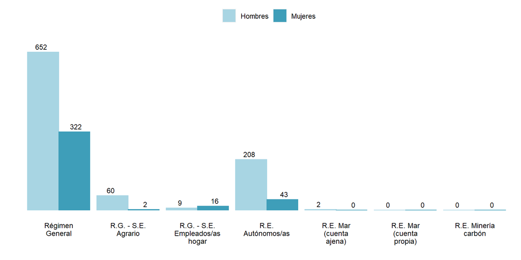

En términos relativos, **el porcentaje de personas afiliadas de nacionalidad tunecina a 28/04/2023 respecto al total de extranjeros de 16 a 64 años de esa nacionalidad residentes a 31/12/2022 es del 65%**; en los hombres ese porcentaje es del 74% y en las mujeres, 50%.

| Sexo | Afiliados | % afiliados sobre residentes de 16 a 64 años |
| --- | --- | --- |
| TOTAL | 1.314 | 65 |
| Hombres | 931 | 74 |
| Mujeres | 383 | 50 |

Nota: Los afiliados son a fecha 28/04/2023 y los residentes a 31/12/2022.

Fuente: [Seguridad Social - MISSM](https://www.seg-social.es/wps/portal/wss/internet/EstadisticasPresupuestosEstudios/Estadisticas/EST8/EST10/EST305/EST307/EST314)

4.2 Parados registrados en el SEPE nacionales de Túnez (abril 2023)

Hay en España **183 parados registrados nacionales de Túnez**, 104 (57%) hombres y 79 (43%) mujeres.

| TOTAL | Sexo Hombres | Sexo Mujeres | Grupo de edad 16-24 años | Grupo de edad 25-34 años | Grupo de edad 35-44 años | Grupo de edad 45-54 años | Grupo de edad 55 y más años |
| --- | --- | --- | --- | --- | --- | --- | --- |
| 183 | 104 | 79 | 6 | 40 | 78 | 30 | 29 |
| % | 57 | 43 | 3 | 22 | 43 | 16 | 16 |

Parados registrados en el SEPE nacionales de Túnez según comunidad autónoma, abril 2023. Cifras absolutas y porcentaje sobre el total de parados extranjeros registrados de nacionalidad tunecina

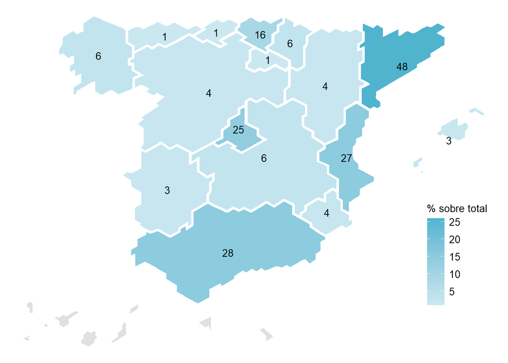

Fuente: [Servicio Público de Empleo Estatal (SEPE)](https://www.sepe.es/HomeSepe/que-es-el-sepe/estadisticas.html)

# 5. Nacionalizados españoles por residencia

Además de la adquisición originaria, el Código Civil considera diferentes modos de **adquisición de la nacionalidad española**:

- **Por adopción**: los extranjeros menores de 18 años adoptados por un español.
- **Por opción**:  
  - Las personas que estén o hayan estado sujetas a la patria potestad de un español.  
  - Las personas cuyo padre o madre hubiera sido originariamente español y nacido en España.  
  - Las personas cuya filiación (identificación de quiénes son sus progenitores) o nacimiento en España se determine después de haber cumplido los 18 años.  
  - Los extranjeros mayores de 18 años adoptados por un español.
- **Por carta de naturaleza**: otorgada discrecionalmente mediante Real Decreto cuando en el interesado concurran circunstancias especiales.
- **Por residencia**, otorgada por el Ministerio de Justicia cuando concurran los siguientes requisitos:  
  1. Haber residido en España un plazo de tiempo que varía según el supuesto.  
  2. La residencia debe ser legal, continuada e inmediatamente anterior a la solicitud.  
  3. El interesado deberá justificar buena conducta cívica y suficiente grado de integración en la sociedad española.
- **Posesión de Estado**: posesión y utilización continuada de la nacionalidad española durante diez años con buena fe y basada en un título inscrito en el Registro Civil.

El 81% del total de adquisiciones de nacionalidad española (no originaria) registradas en el Registro Civil desde 2013 han sido por residencia. En 2022, último periodo publicado por el INE, ese porcentaje fue del 87%.

**Desde 2009 se han nacionalizado españoles por residencia un total de 999 personas con nacionalidad previa tunecina.**

En 2022 obtuvieron la nacionalidad por residencia 71 personas.

Evolución de las concesiones de nacionalidad española por residencia a ciudadanos de Túnez. 2009─2022

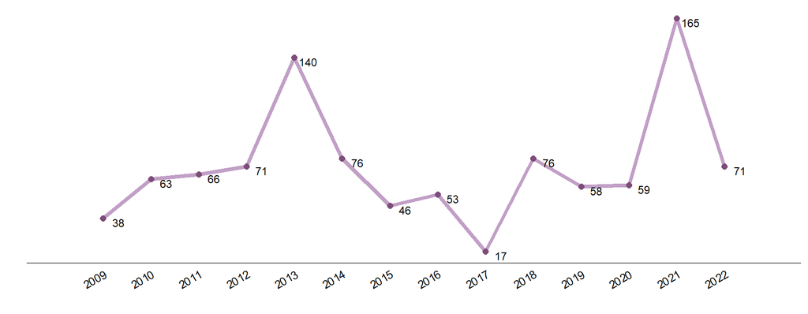

Nota: En 2017 hubo una reducción generalizada de las concesiones de nacionalidad por causas administrativas.

Concesiones de nacionalidad española por residencia a ciudadanos de Túnez según plazo exigido / motivo. 2022

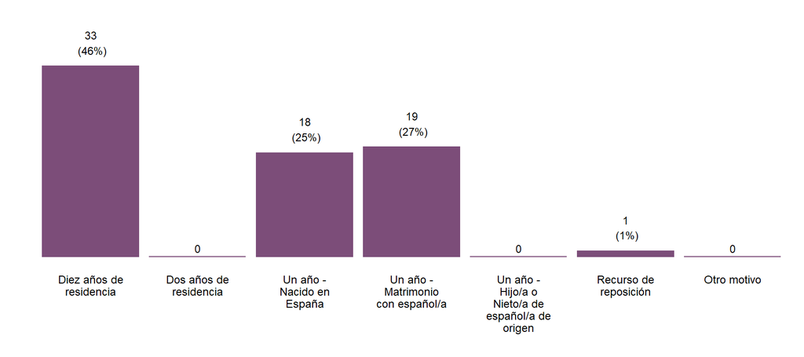

Nota: Existen casos en los que la nacionalidad de origen grabada no coincide con la vía de acceso a la nacionalidad española que debería corresponder según la legislación. Sin embargo, en este momento no se dispone de suficiente información para su correcta depuración.

Concesiones de nacionalidad española por residencia a ciudadanos de Túnez según sexo y edad. 2022

| TOTAL | Hombres | % Hombres | Mujeres | % Mujeres |
| --- | --- | --- | --- | --- |
| 71 | 42 | 59 | 29 | 41 |

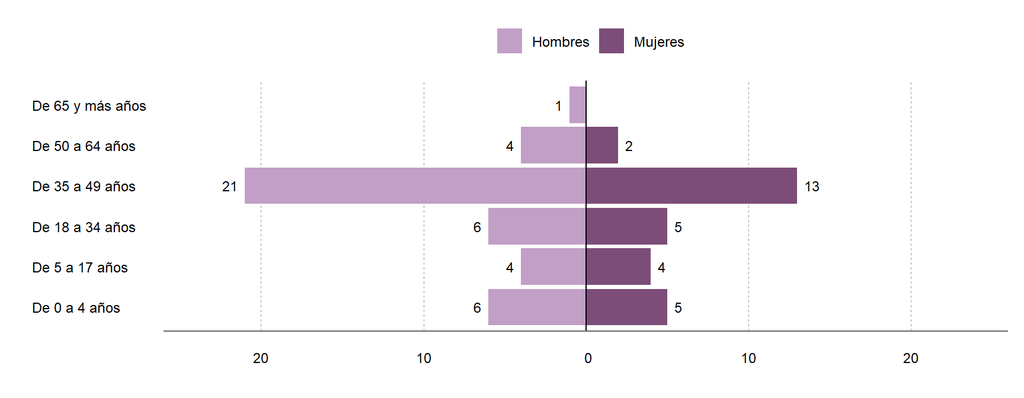

Fuente: [INE](https://www.ine.es/dyngs/INEbase/es/operacion.htm?c=Estadistica_C&cid=1254736177001&menu=resultados&idp=1254735573002), [OPI-SGAM](https://inclusion.seg-social.es/web/opi/estadisticas/catalogo/concesiones_nacionalidad)

# 6. Solicitantes de Protección Internacional

**Durante 2022 24 personas nacionales de Túnez solicitaron Protección Internacional** en el territorio de España, embajadas españolas, puestos fronterizos o CIE. Suponen un 0% del total de solicitantes del periodo.

Según avance mensual, **de enero a mayo de 2023 solicitaron Protección Internacional 26 personas con nacionalidad Túnez**, un 0% del total del periodo.

Evolución de los solicitantes de Protección Internacional nacionales de Túnez y su distribución según sexo. 2017─2022

(No se han publicado aún datos desagregados por sexo para 2022)

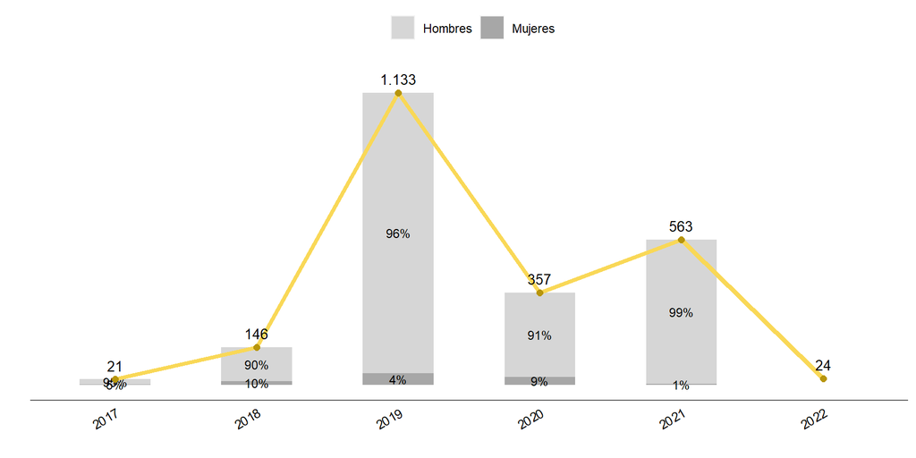

Solicitantes de Protección Internacional nacionales de Túnez según lugar de presentación de la solicitud. 2021

(No se han publicado aún datos para 2022)

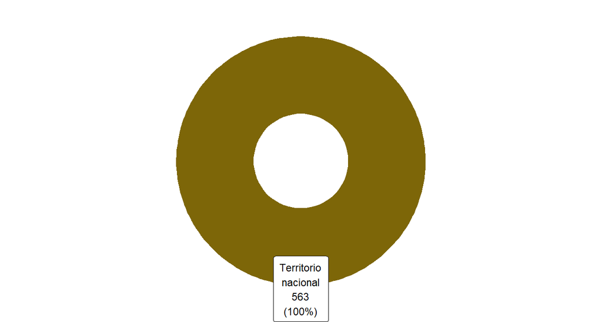

**Durante 2022 se resolvieron 364 solicitudes de Protección Internacional de personas con nacionalidad tunecina.** El 3% fueron favorables.

Evolución de las resoluciones de solicitudes de Protección Internacional de personas nacionales de Túnez. 2017─2022

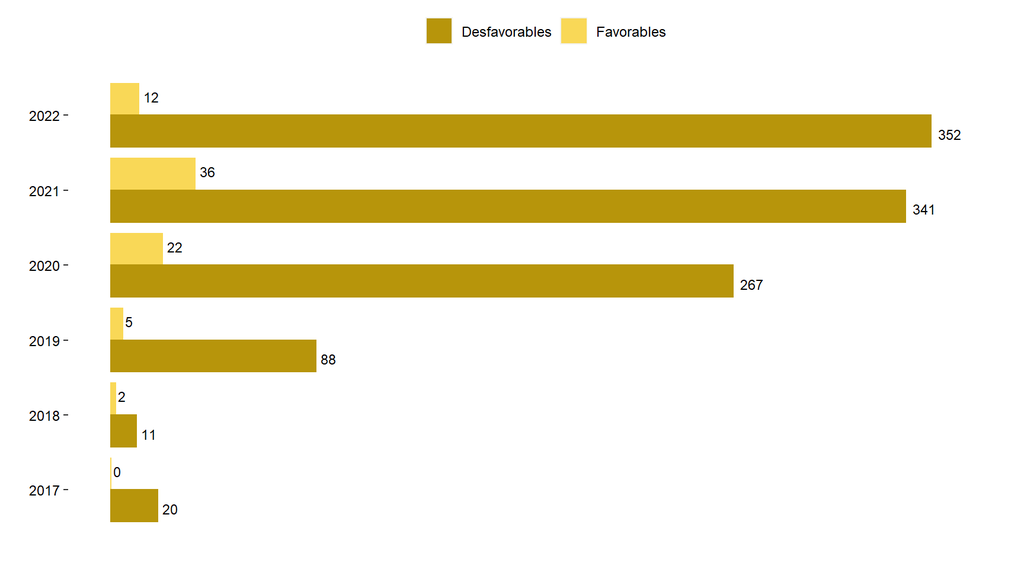

Nota: ‘Favorables’ incluye las resoluciones de reconocimiento de protección internacional (condición de refugiado o derecho a la protección subsidiaria) y las concesiones de autorizaciones de estancia o residencia en España por razones humanitarias.

Tipo de resoluciones de solicitudes de Protección Internacional de personas nacionales de Túnez. 2022

| Resolución | Personas | % |
| --- | --- | --- |
| TOTAL | 364 | 100 |
| Reconocimiento condición de refugiado | 12 | 3 |
| Reconocimiento derecho a la protección subsidiaria | 0 | 0 |
| Autor. estancia o residencia por razones humanitarias | 0 | 0 |
| Resolución desfavorable | 352 | 97 |

Propuestas de resolución de solicitudes de Protección Internacional de personas nacionales de Túnez elevadas a la Comisión Interministerial de Asilo y Refugio. Enero─mayo 2023

| Criterio de resolución | Propuestas | % |
| --- | --- | --- |
| TOTAL | 21 | 100 |
| Estatuto de refugiado | 4 | 19 |
| Protección subsidiaria | 0 | 0 |
| Razones humanitarias | 0 | 0 |
| Desfavorables | 12 | 57 |
| Archivo | 5 | 24 |

Fuente: [Oficina de Asilo y Refugio - Ministerio del Interior](https://www.interior.gob.es/opencms/es/servicios-al-ciudadano/tramites-y-gestiones/oficina-de-asilo-y-refugio/datos-e-informacion-estadistica/)

# 7. Beneficiarios del Sistema de Acogida y del programa de Atención Humanitaria

**Actualmente constan 22 personas de Túnez en el Sistema de Acogida para Refugiados, Inmigrantes y Solicitantes de Asilo o en plazas de Atención Humanitaria**; suponen el 0% del total de beneficiarios. 16 (73%) hombres y 6 (27%) mujeres.

Nacionales de Túnez beneficiarios del Sistema de Acogida o del programa de Atención Humanitaria según sexo y tipo de recurso. 30/05/2023

[output not shown]

Nacionales de Túnez beneficiarios del Sistema de Acogida o del programa de Atención Humanitaria según comunidad autónoma de acogida. 30/05/2023

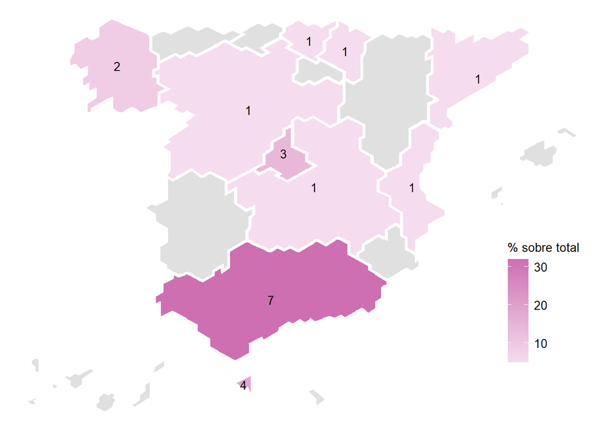

Fuente: elaborado por SGAM-OPI a partir de información de la aplicación SIRIA (Sistema de Información sobre Programas para Refugiados, Inmigrantes y Solicitantes de Asilo) del [MISSM](https://inclusion.seg-social.es/web/migraciones/acogida-y-atencion-humanitaria)

# 8. Menores extranjeros no acompañados y jóvenes extutelados (de 16 a 23 años)

**A 30/11/2022 había 7 menores no acompañados o jóvenes extutelados, de 16 a 23 años, de Túnez** con una autorización de residencia en vigor, el 0% del total. 7 son chicos (100%) y 0 chicas (0%).

Menores no acompañados o jóvenes extutelados, de 16 a 23 años, de Túnez con autorización de residencia según tipo de autorización. 30/11/2022

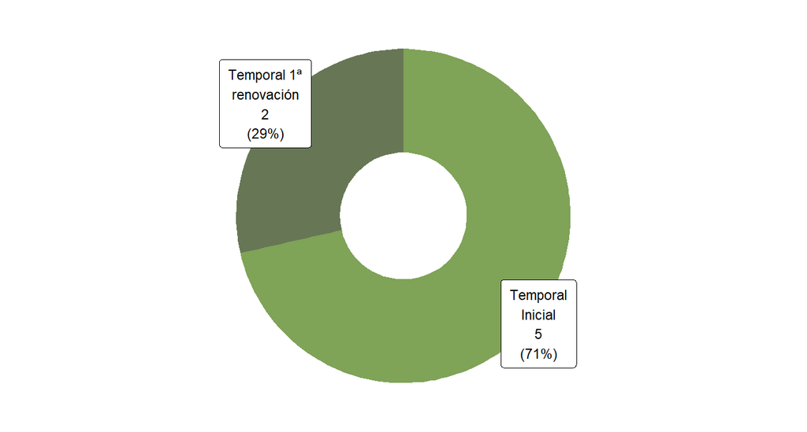

Evolución bimensual de los menores no acompañados o jóvenes extutelados, de 16 a 23 años, de Túnez, julio 2021 ─ noviembre 2022

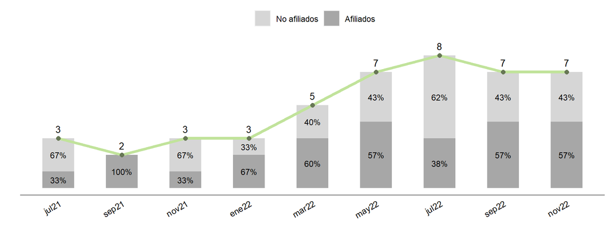

Fuente: [OPI-SGAM](https://inclusion.seg-social.es/web/opi/estadisticas/catalogo/menores)

# 9. Evolución de los flujos regulares (visados y documentación de residencia)

9.1 Flujo de visados

Evolución de visados concedidos a ciudadanos de Túnez según clase de visado. 2013─2022

| Clase | 2013 | 2014 | 2015 | 2016 | 2017 | 2018 | 2019 | 2020 | 2021 | 2022 | % 2022 |
| --- | --- | --- | --- | --- | --- | --- | --- | --- | --- | --- | --- |
| TOTAL | 7.606 | 8.230 | 6.921 | 7.788 | 7.342 | 6.740 | 7.255 | 3.018 | 3.488 | 9.738 | 100 |
| Corta duración | 7.444 | 8.075 | 6.730 | 7.568 | 7.054 | 6.352 | 6.767 | 2.616 | 2.827 | 8.720 | 90 |
| Larga duración | 162 | 155 | 190 | 220 | 288 | 388 | 488 | 401 | 661 | 1.017 | 10 |
| Tránsito aeroportuario | 0 | 0 | 1 | 0 | 0 | 0 | 0 | 1 | 0 | 1 | 0 |

Evolución de visados concedidos a ciudadanos de Túnez según clase de visado de corta o larga duración. 2010─2022

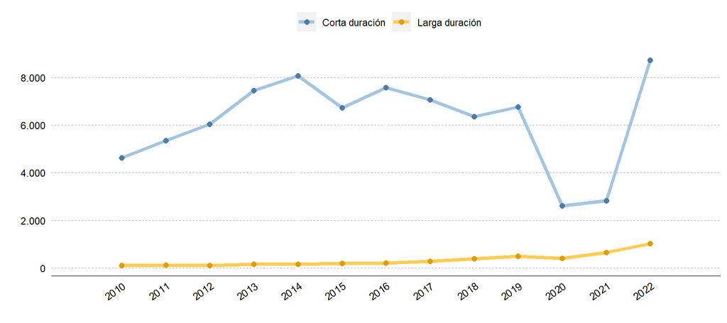

Visados expedidos a nacionales de Túnez según clase (corta o larga duración) y tipo/finalidad de visado. 2022

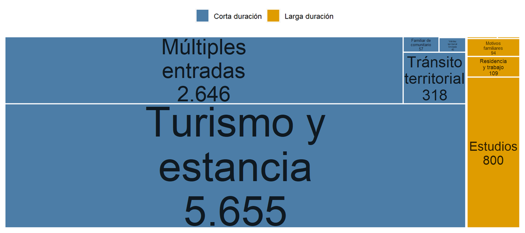

Fuente: [OPI-SGAM](https://inclusion.seg-social.es/web/opi/estadisticas/catalogo/visados)

Los visados de larga duración generalmente dan lugar a documentación de residencia.

9.2 Flujo de documentación de residencia

En los últimos 5 años se ha concedido o expedido documentación de residencia (autorizaciones de residencia o tarjetas de familiar de UE/AELC o de británico) a nacionales de Túnez por los siguientes motivos:

Autorizaciones de residencia concedidas a ciudadanos de Túnez según motivo. 2017─2021

| Motivo | 2017 | 2018 | 2019 | 2020 | 2021 |
| --- | --- | --- | --- | --- | --- |
| TOTAL | 209 | 282 | 316 | 283 | 354 |
| Residencia temporal. Ley 14/2013 y otras | 60 | 71 | 115 | 105 | 148 |
| Residencia temporal no lucrativa | 16 | 49 | 80 | 39 | 62 |
| Residencia larga duración nacional | 51 | 67 | 49 | 51 | 60 |
| Residencia temporal. Trabajo por cuenta ajena | 30 | 36 | 19 | 30 | 28 |
| Residencia temporal. Circunstancias excepcionales | 11 | 9 | 8 | 13 | 26 |
| Residencia temporal. Reagrupación familiar | 21 | 30 | 28 | 25 | 21 |
| Residencia larga duración Directiva UE | 4 | 7 | 5 | 5 | 5 |
| Residencia temporal. Trabajo por cuenta propia | 11 | 8 | 7 | 7 | 3 |
| Residencia temporal. Excepción a la autorización de trabajo | 5 | 5 | 4 | 6 | 1 |
| Residencia duración determinada. Trabajo por cuenta ajena | 0 | 0 | 1 | 0 | 0 |
| Residencia temporal. Compatibilidad cuenta ajena y propia | 0 | 0 | 0 | 2 | 0 |

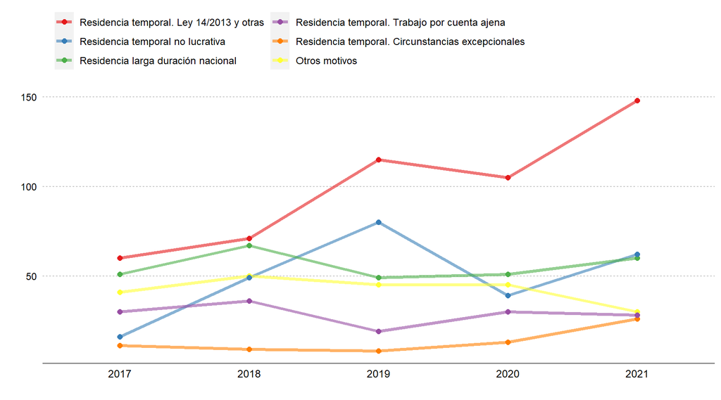

Tarjetas de familiar de ciudadano UE/AELC o TIE de familiar de británico beneficiario del acuerdo de retirada expedidas a nacionales de Túnez, según motivo. 2017─2021

| Motivo | 2017 | 2018 | 2019 | 2020 | 2021 |
| --- | --- | --- | --- | --- | --- |
| TOTAL | 104 | 96 | 124 | 96 | 122 |
| Familiar de UE-RU. Temporal | 59 | 67 | 77 | 66 | 77 |
| Familiar de UE-RU. Permanente | 45 | 29 | 47 | 30 | 45 |

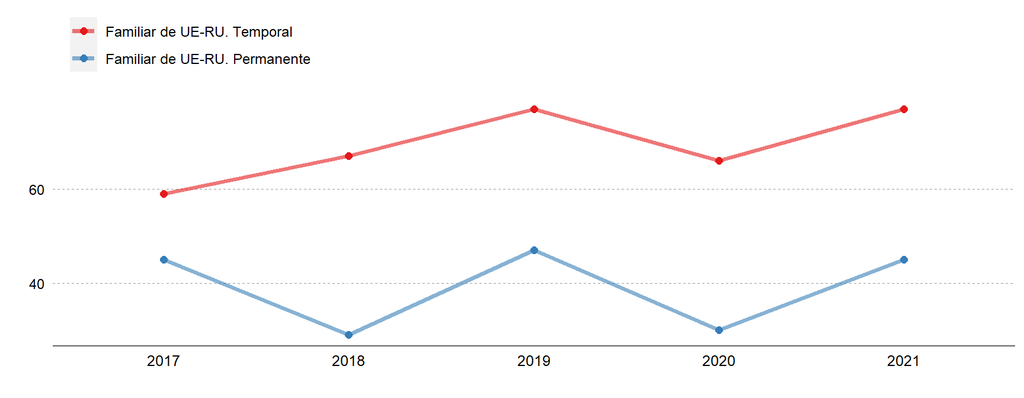

El siguiente gráfico muestra la **distribución de la documentación de residencia (autorizaciones de residencia o tarjetas de familiar de UE/AELC o de británico) concedida o expedida a nacionales de Túnez durante 2021, según tipo de trámite**:

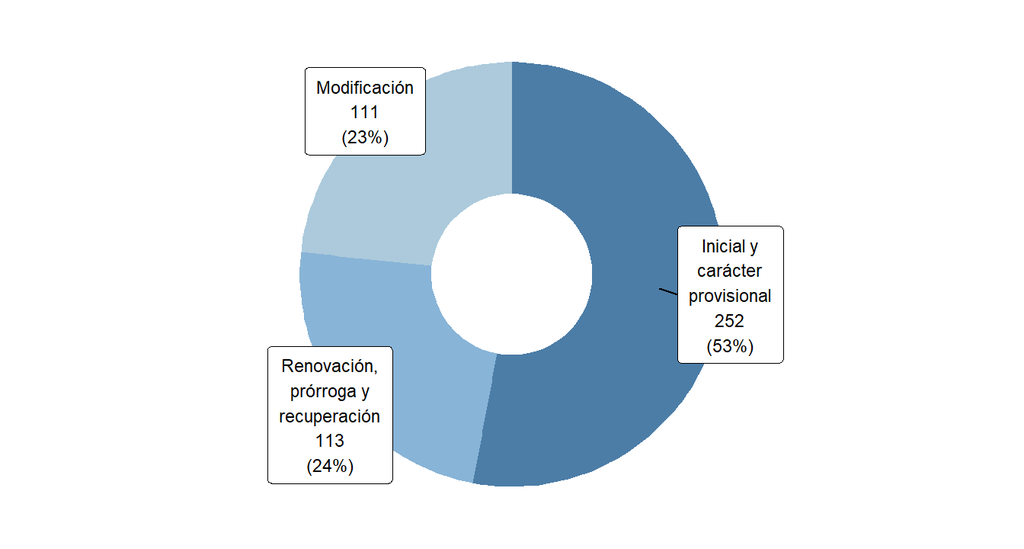

Fuente: [OPI-SGAM](https://inclusion.seg-social.es/web/opi/estadisticas/catalogo/flujo_autorizaciones)

**Comparando con el resto de países de la UE/AELC, el siguiente mapa muestra el número de *primeras* autorizaciones de residencia o de estancia por estudios expedidas a personas de nacionalidad tunecina durante 2021**, entendiendo como *primera* aquella autorización concedida a una persona si no le fue concedida ninguna otra en los 6 meses anteriores.

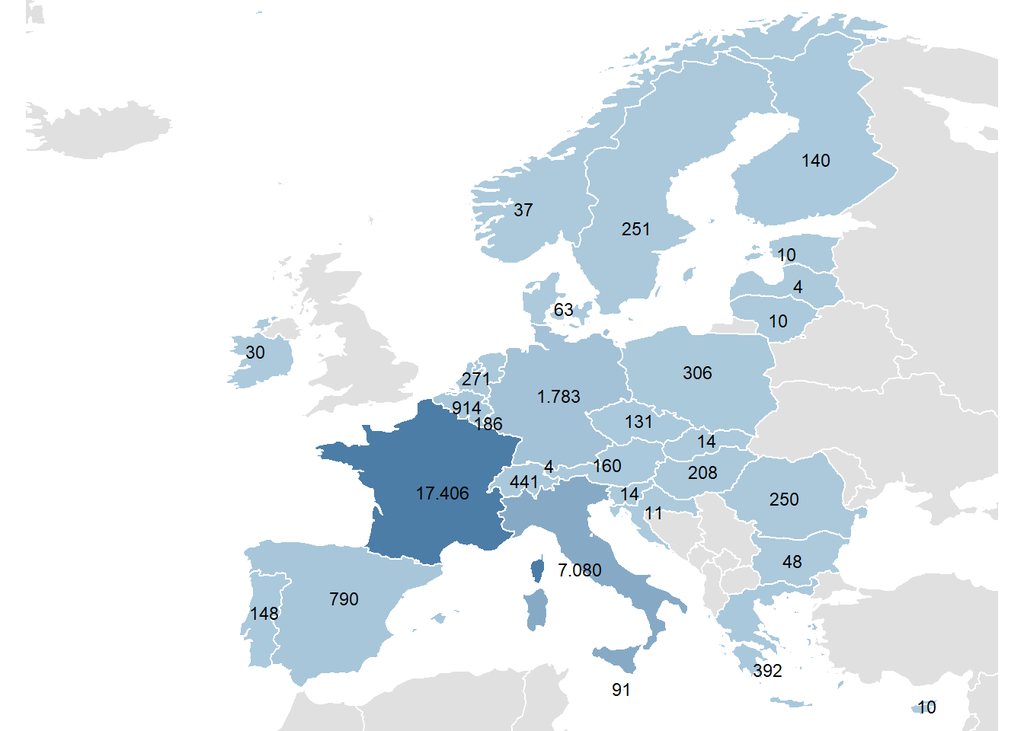

Sin dato disponible: Islandia

Fuente: [Eurostat](https://ec.europa.eu/eurostat/databrowser/view/migr_resfirst/default/table?lang=en)

# 10. Población española residente en Túnez

**A 01/01/2023, último dato publicado por el INE, había 576 españoles residentes en Túnez** inscritos en el fichero central del Padrón de españoles residentes en el extranjero (PERE); suponen el 2% de todos los españoles residentes en países de África.

| TOTAL | Hombres | % Hombres | Mujeres | % Mujeres |
| --- | --- | --- | --- | --- |
| 576 | 275 | 48 | 301 | 52 |

Evolución de los españoles residentes en Túnez inscritos en el PERE. 2009─2023

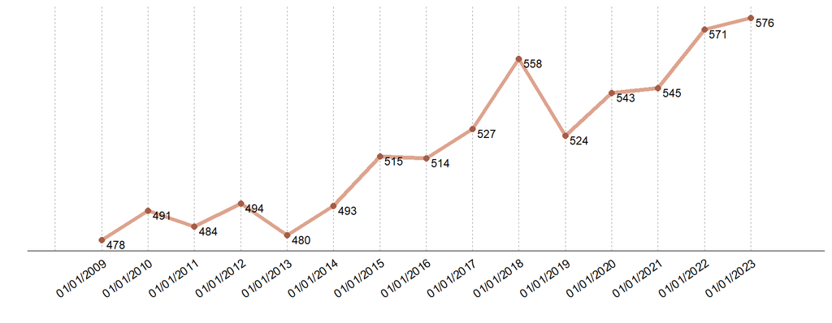

Fuente: [PERE - INE](https://www.ine.es/dyngs/INEbase/operacion.htm?c=Estadistica_C&cid=1254736177014&menu=resultados&secc=1254736195474&idp=1254734710990)